# Distribución de Rademacher

2025-04-24

## 🧠 **Marco Teórico**

## 🎯 Definición

La **distribución de Rademacher** es una variable aleatoria discreta con valores:

\[ \epsilon = \begin{cases} +1 & \text{con probabilidad } 0.5, \\ -1 & \text{con probabilidad } 0.5. \end{cases} \]

- **Parámetros**: distribución fija, no tiene parámetros ajustables.

## 🔢 Función de Masa de Probabilidad (PMF)

\[ P(\epsilon = k) = \begin{cases} 0.5 & \text{si } k = \pm 1, \\ 0 & \text{en otro caso}. \end{cases} \]

- **Visualización**: Dos barras en -1 y +1 con altura 0.5.

## 📈 Función de Distribución Acumulada (CDF)

\[ F_\epsilon(k) = \begin{cases} 0 & \text{si } k < -1, \\ 0.5 & \text{si } -1 \leq k < 1, \\ 1 & \text{si } k \geq 1. \end{cases} \]

- Salto de 0.5 en cada punto.

## ⚙️ Propiedades

### 🔹 Media

\[ \mathbb{E}[\epsilon] = (+1)(0.5) + (-1)(0.5) = 0 \]

### 🔹 Varianza

\[ \text{Var}(\epsilon) = \mathbb{E}[\epsilon^2] - (\mathbb{E}[\epsilon])^2 = 1 - 0 = 1 \]

### ✨ Propiedades clave

- **Simetría**: \(\epsilon\) es simétrica respecto a 0.
- **MGF** (Moment Generating Function):

\[ M_\epsilon(t) = \frac{e^t + e^{-t}}{2} = \cosh(t) \]

## 🧩 **Ejemplo Aplicado**

**Problema**: Si \(\epsilon_1, \epsilon_2\) ~ Rademacher independientes, ¿cuál es la probabilidad de que el producto sea -1?

\[ P(\epsilon_1 \cdot \epsilon_2 = -1) = 0.25 + 0.25 = 0.5 \]

## 🛠️ **Aplicaciones Prácticas**

- **Aprendizaje Automático**: Complejidad de Rademacher en VC-dimension.
- **Teoría de Probabilidad**: Desigualdad de Hoeffding.
- **Caminatas Aleatorias**: Sumas de variables Rademacher.
- **Procesamiento de Señales**: Proyecciones aleatorias en compresión de datos.

## 📊 Problema tipo examen

**Enunciado**: Se lanza una moneda 100 veces, donde  
- Cara = \(+1\)  
- Cruz = \(-1\)  
Sea \(S_{100} = \sum \epsilon_i\). Estimar:

\[ P(|S_{100}| \leq 10) \]

**Solución**: Aproximación por el Teorema Central del Límite:

\[ S_{100} \sim \mathcal{N}(0, 100) \Rightarrow P(-10 \leq Z \leq 10) \approx 0.6826 \]

## 💻 **Simulación en R**

## 🔢 Generación de datos

```r
set.seed(123)
epsilon <- sample(c(-1, 1), 1000, replace = TRUE)
mean(epsilon)  # ≈ 0
```

```
## [1] -0.012
```

```r
var(epsilon)   # ≈ 1
```

```
## [1] 1.000857
```

## 📊 Visualización de la distribución

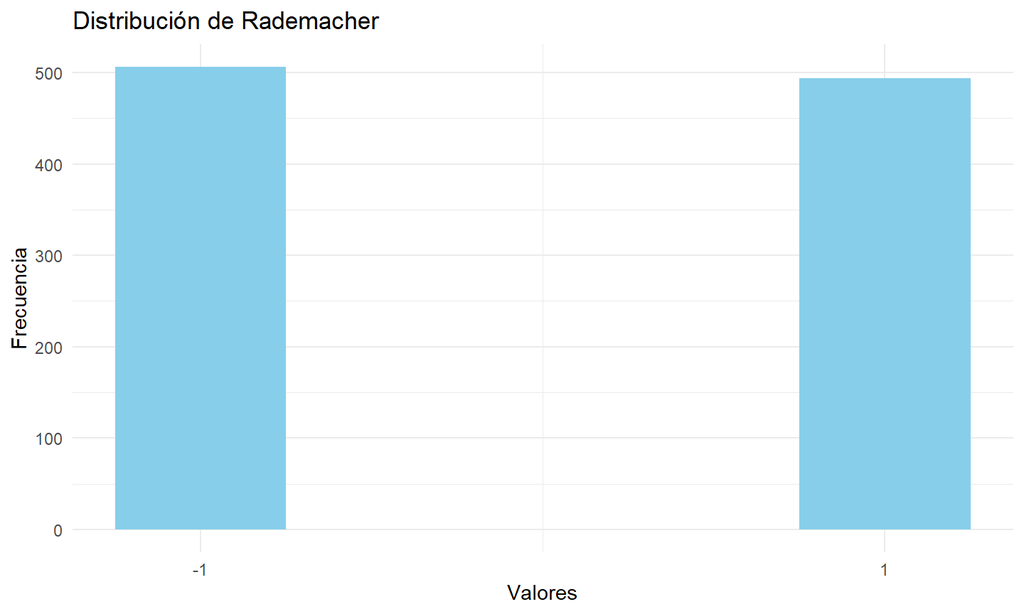

```r
library(ggplot2)
ggplot(data.frame(x = epsilon), aes(x)) +
  geom_bar(width = 0.5, fill = "skyblue") +
  scale_x_continuous(breaks = c(-1, 1)) +
  labs(title = "Distribución de Rademacher", x = "Valores", y = "Frecuencia") +
  theme_minimal()
```

## 📋 Comparación Teoría vs. Simulación

[output not shown]

## 🙌 **¡Muchas Gracias!**

**Ingeniería Estadística**  
**Escuela Colombiana de Ingeniería Julio Garavito**  
**Fundamentos de Probabilidad (MATE FPRO-1)**

“La estadística es la gramática de la ciencia.”